# Desafio #02 - CE302 Visualização de Dados Aplicada

2024-10-14

Alunos: João Victor Pietchaki Gonçalves, Lenardo Eizo Sakai

Desafio #02 - CE303 - Prof. Dr. Anderson Ara - DEST/UFPR - 2024/2

## O que é o **Gráfico de Funil?**

Simples mas efetivo, esse o **Gráfico de Funil** se tornou famoso dentro do marketing digital para representar dados de funis de vendas. Afinal, um gráfico de funil é usado para mostrar dados de fluxo linear, onde cada fatia no funil representa um processo que filtrou dados. Ao visualizar o número de usuários que chegam a cada estágio do processo, uma empresa pode entender onde há quedas significativas e tentar fazer mudanças na experiência do usuário para melhor. A última etapa do funil contém o valor que é o resultado final de todo o procedimento.

Idealmente, o gráfico de funil mostra um processo que começa em 100% e termina com uma porcentagem menor, onde é perceptível em quais estágios a queda acontece e em que taxa.

Observe que não haverá detalhes suficientes em um gráfico de funil para dizer por que uma queda inesperada ocorreu, então os funis são melhor usados como uma visualização de alto nível antes de passar para uma investigação mais profunda.

## Exemplo Prático

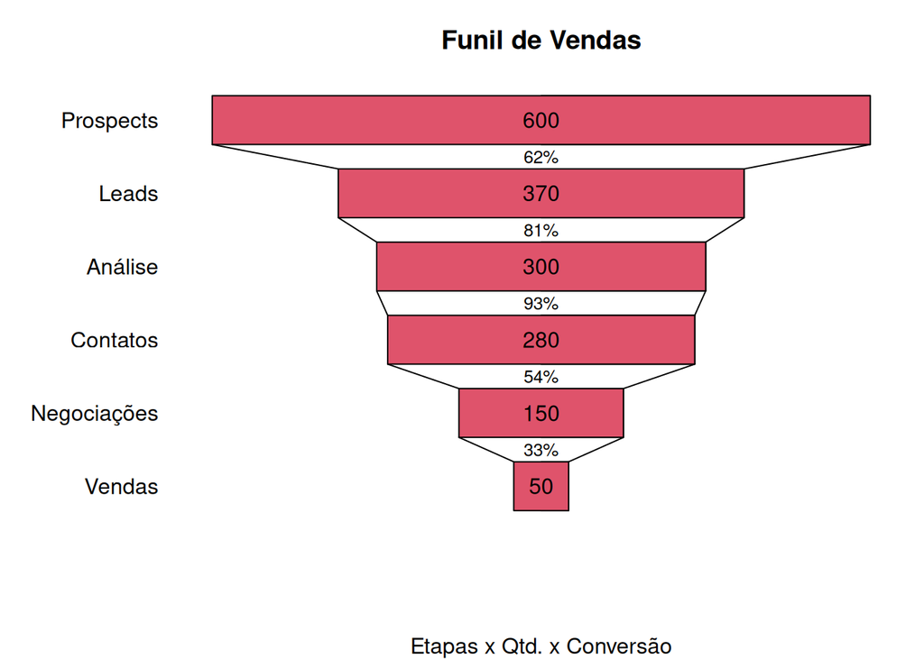

```r
# Define os fatores
nome <- factor(c("Prospects","Leads","Análise","Contatos","Negociações","Vendas"), ordered = T)

# Define a base de dados
quantidade <- setNames(c(600,370,300,280,150,50), nome)

# D
par(mar = c(5,7,3,1))

# Cria um gráfico de funil a partir de um gráfico de barras empillhadas
p <- barplot(rbind(sort(quantidade),sort(-quantidade*2, decreasing = T)),
        horiz = T,
        xlim = c(-650,650),
        axes = F,
        space = .5,
        las=2,
        main = "Funil de Vendas",
        sub = "Etapas x Qtd. x Conversão",
        col = quantidade)

# Adiciona os valores nas barras
text(sort(quantidade), y = p, x = 0)

# Adiciona a taxa de conversão entre as  barras
text(paste0(100*round(quantidade[2:6]/(quantidade[1:5]),2),"%"), y = p[6:2]-.75, x = 0, cex=.8)

# Adiciona as linhas entre as barras
segments(quantidade[1:5], p[6:2]-.5, quantidade[2:6], p[5:1]+.5)
segments(-quantidade[1:5], p[6:2]-.5, -quantidade[2:6], p[5:1]+.5)
```

## Fontes

- ATLASSIAN. Funnel chart: complete guide. Disponível em: https://www.atlassian.com/data/charts/funnel-chart-complete-guide. Acesso em: 13 out. 2024.
- DATA VIZ PROJECT. Funnel chart. Disponível em: https://datavizproject.com/data-type/funnel-chart/. Acesso em: 13 out. 2024.
- WOLKE, M. Funnel analysis. Kaggle, [s.d.]. Disponível em: https://www.kaggle.com/code/mpwolke/funnel-analysis/notebook. Acesso em: 13 out. 2024.